# Redes Neuronales Recurrentes

Minería de datos. Master en Tecnologías de Análisis de Datos Masivos: Big Data

Aurora González Vidal, `aurora.gonzalez2@um.es`

24 de Marzo de 2025

# 1 Introducción

Una característica principal de redes como los MLPs es que tratan cada variable de entrada de manera independiente, sin asumir un orden entre ellas (ej: características en un vector). Sin embargo, las CNNs sí consideran el orden espacial o local (como píxeles en una imagen), pero no modelan dependencias temporales secuenciales. En cambio, las RNNs están diseñadas explícitamente para datos donde el orden temporal es crucial, como series de tiempo o texto.

## 1.1 Datasets concretos y la noción de secuencialidad

Veamos qué significa la noción de secuencialidad en ejemplos concretos. Cuando nos referimos a una secuencia, estamos hablando de un conjunto de símbolos o números

$$a_1, a_2, \ldots, a_{t-1}, a_t, a_{t+1},
\ldots$$

tales que $a_{t-1}$ precede a $a_t$ y esta a $a_{t+1}$.

En el caso del dataset Iris, tenemos varias variables como la longitud y el ancho del sépalo, la longitud y el ancho del pétalo, y la especie de la flor. Todos estos atributos han sido obtenidos de manera independiente para cada muestra y no tiene sentido pensar en ellos en términos de cuál va antes o después en el tiempo.

En el problema MNIST tenemos píxels, que conforman imágenes con dígitos escritos a mano.

Cuando los introducimos en un MLP, los tratamos de manera independiente. Tratamos de la misma forma, y en paralelo, píxels de la esquina superior izquierda que aquellos que están en el centro de la imagen.

Cuando los pasamos primero por filtros convolucionales en una red de convolución, tenemos presente la noción de píxels próximos en la imagen ya que los filtros (1) abarcan un tamaño que integra en un mismo valor final, píxels que están próximos en la imagen y (2) existe overlap entre áreas de aplicación de filtros consecutivas (sobre todo cuando el valor de salto, *stride* es pequeño). Pero una vez hecho esto, el resultado desemboca en un MLP, que termina tratando a todos los valores de los mapas de características por igual.

¿Qué ocurre si aplicamos ambos enfoques a un texto o a una serie temporal?

- En un texto: ¿tendría sentido trabajar con un texto como si las palabras en un folio en blanco fueran los píxels de nuestras imágenes? ¿Qué ocurriría en ese caso si usamos un MLP? ¿Y si usamos una convolución?
- En una serie temporal (e.g., valor bursátil para las acciones de las empresas del IBEX 35) ¿Cómo de similar sería el problema? ¿Podemos aplicar aquí una convolución?

## 1.2 La idea básica en recurrencia

Un enfoque encargado de computar secuencias de manera más cercana a como lo hacemos los humanos sería la siguiente:

> Cuando leemos un texto procesamos la información palabra a palabra.

Para entender el significado de una nueva palabra de manera apropiada, necesitamos las palabras anteriores. Nuestra comprensión del texto no surge de analizar cada palabra de forma aislada, sino de construir progresivamente el significado mediante el contexto. Este proceso implica que mantenemos un modelo interno de lo que hemos leído, que se actualiza dinámicamente con cada nueva palabra.

# 2 Redes neuronales recurrentes

Una red neuronal recurrente (RNN) tiene en cuenta estados anteriores en el tiempo para predecir estados actuales.

- Procesa secuencias iterando sobre los elementos de las mismas y manteniendo un estado que contiene información de lo que ha visto hasta el momento.
- El estado de la red se restaura cada vez que se termina de procesar una secuencia para procesar la siguiente.
  - Una secuencia es una sola entrada a la red.
- Lo que cambia con respecto a las redes convencionales es que cada muestra no se procesa en un solo paso, sino que la red internamente itera sobre los elementos de la secuencia.

En la figura siguiente podemos verlo.

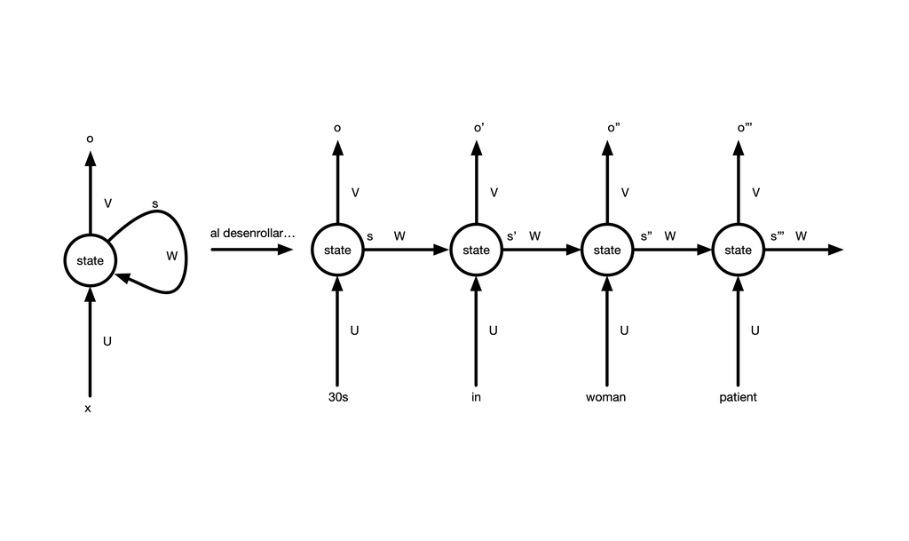

A la izquierda vemos la representación simplificada de una red recurrente, a la derecha, la red desenrollada cuando le vamos introduciendo palabras de manera secuencial, en su orden adecuado.

## 2.1 Parámetros de una red recurrente

A la izquierda tenemos la red colapsada en un módulo global, que se realimenta de su propia salida. En ella ya se ven los parámetros del modelo: las matrices $U$, $W$ y $V$. Más concretamente:

- $x$ es un token a la entrada, en este caso de longitud fija $n$. Dicho token forma parte de un ejemplo a la entrada, que tendrá longitud variable. En la figura anterior, el ejemplo completo es $(x=\text{patient}, x=\text{woman}, x=\text{in}, x=\text{30s})$.
- Los cuatro elementos de la secuencia, patient, woman, in, 30s, han de tratarse para que tengan la misma longitud. ¿Cómo logramos esto?
- Con $s$ denotamos al estado de la red en un instante concreto
- Con $o$ nos referimos a la salida o predicción de la red una vez se genera su estado $s$

Sobre las matrices de parámetros del modelo:

- $U \in \mathbb{R}^{n \times d}$ nos sirve para parametrizar la forma en la que tratamos individualmente cada token a la entrada. Podemos verlo como una capa fully-connected de un MLP. En $d$ tenemos el número de nodos ocultos de la red.
- $W \in \mathbb{R}^{d \times d}$ nos sirve para parametrizar la relación entre el estado actual $s_t$ y el estado anterior $s_{t-1}$. Esta sería la capa que modela la relación recursiva entre el estado actual y el estado anterior.
- $V \in \mathbb{R}^{d \times k}$ parametriza la salida de la red ya que necesita del estado actual $s_t$ y genera la salida de la red $o_t$ en el mismo instante. Si el problema es de clasificación, $k>1$ será el número de clases a la salida. Este último puede ser también de salida de MLP.

Por tanto, $s_t \in \mathbb{R}^d$, el estado en el instante $t$, es función de $U$ y $W$ tal que:

$$s_t = f(Ux_t + Ws_{t-1} +
b_s)$$

en donde $f$ es una función de activación derivable.

Lo que nos está diciendo esta expresión es que:

- El valor del estado $s$ en el instante $t$ ya no solo depende de los pesos de los arcos que conectan las entradas con la capa oculta, como sí ocurre en el caso de un MLP. Ahora, además, depende del resultado de modular el valor del estado anterior, $s_{t-1}$ mediante la matriz $W$.
- Lo que antes era una sola multiplicación de matrices para obtener el valor de un estado, ahora se transforma en una multiplicación recurrente (i.e. cada vez, la expresión es la misma y depende de la misma definición) de matrices hacia atrás.
- Las matrices $U$, $W$ y $V$ tienen siempre el mismo tamaño y no cambian conforme se va avanzando en el tiempo, dentro de cada ejemplo de entrenamiento.
- La salida $o$ es una secuencia: cada $x$ genera una predicción, $o_t \in \mathbb{R}^k$, tal que:

$$o_t = f'(Vs_t + b_o),$$

siendo $f'()$ otra función de activación (e.g. una softmax).

A la derecha de la figura de arriba vemos una RNN desenrollada. Con desenrollada nos referimos a que hemos mostrado cómo quedaría la red para la secuencia completa (o más bien una trozo general de ella). Este despliegue es realmente simbólico, solo ocurre a nivel de cálculo. No se representa la red en memoria. Además, nótese que las matrices $U$, $W$ y $S$ no cambian durante el proceso feed-forward de predicción.

$$\begin{aligned}
s_a &= f(Ux_a + b_s) \rightarrow o_a = f'(Vs_a + b_o) \\
s_c &= f(Ux_c + Ws_a + b_s) \rightarrow o_c = f'(Vs_c + b_o) \\
s_e &= f(Ux_e + Ws_c + b_s) \rightarrow o_e = f'(Vs_e + b_o) \\
s_g &= f(Ux_g + Ws_e + b_s) \rightarrow o_g = f'(Vs_g + b_o)
\end{aligned}$$

Cada una de estas capas tiene un número de nodos que se le han de especificar cuando se ejecute el modelo, como veremos en Keras.

Algo muy importante de este tipo de redes es que deben funcionar para longitudes diferentes de las entradas. Por ello, necesitamos que, en cada paso, se ejecute la misma función para calcular el estado de la red, ya que si usáramos diferentes pesos $U$, $W$ y $V$ para cada tiempo $t$, no podríamos generalizar a secuencias de diferente tamaño a las usadas en el entrenamiento.

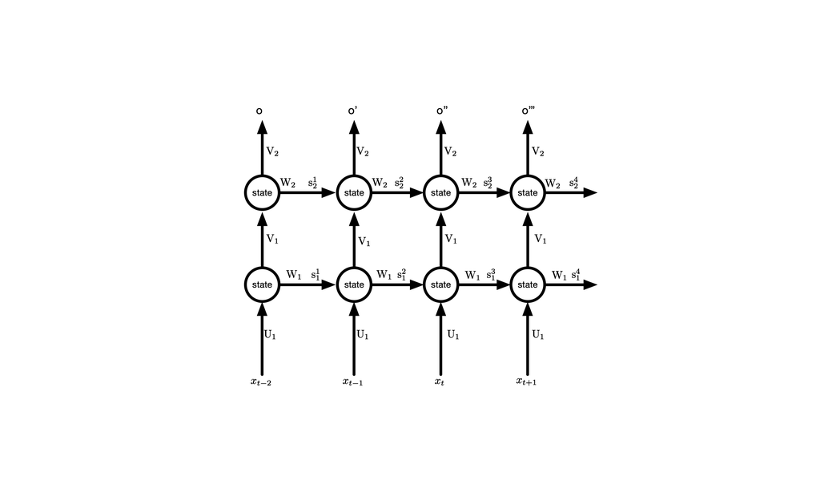

En el caso de las redes neuronales convencionales se usan varias capas para poder crear una representación jerárquica de las características de los datos de entrada para predecir la variable de salida. Lo mismo aplica para todas las redes recurrentes.

## 2.2 Recapitulando

- El estado $s_t$ puede verse como un nodo con memoria, ya que captura información sobre lo que ha pasado en los pasos previos ya que $s_t = f(Ux_t + Ws_{t-1} + b_s)$.
- La salida en el instante $t$, $o_t$, se calcula basándonos en lo que sabemos en ese momento, pero es importante remarcar que, gracias al estado $s_t$, podemos asegurar que la salida $o_t$ depende de todas las entradas pasadas, ya que $s_t$ depende de $s_{t-1}$, que depende de su entrada $x_{t-1}$ y del estado $s_{t-2}$ y así sucesivamente.
- Una RNN usa una matriz de pesos adicional para una red, en comparación a una MLP de 1 capa, la matriz $W$, siendo el conjunto de matrices $(U,W,V,b)$ entre todos los pasos. Esto refleja el hecho de que estamos realizando la misma tarea para cada paso, solo que con diferentes entradas. Gracias a ello, el número total de parámetros que debemos aprender se reduce considerablemente.
- El diagrama mostrado arriba tiene salidas en cada paso, pero dependiendo de la tarea esto puede no ser necesario. Por ejemplo, para predecir el sentimiento de una frase solo necesitaríamos la salida final de la red (la de la última capa).

A la hora de aplicar las RNN en la práctica, algunas veces simplemente tenemos que mirar a información reciente para predecir la tarea actual, pero este no es siempre el caso. Por ejemplo, puede ocurrir que queramos predecir la siguiente palabra en una frase y esta sea:

> “Cuando era un niño crecí en Alemania,…, hablo muy bien el alemán”.

La información reciente sugiere que la siguiente palabra es el nombre de un idioma, pero si queremos saber cuál es, probablemente tengamos que extraer el contexto de Alemania de muchos pasos atrás.

# 3 Las diferentes modalidades

Las diferentes modalidades se ven en la siguiente figura:

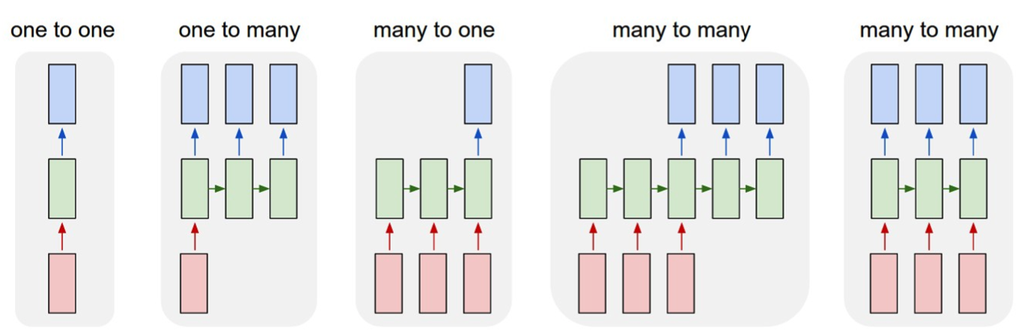

Modalidades de red recurrente

En esta figura, del curso de [Johnson en UMich](https://web.eecs.umich.edu/~justincj/teaching/eecs498/WI2022/), de izquierda a derecha tenemos:

- One-to-one

Lo que vemos es un ejemplo típico de red neuronal clásica en el que tenemos una entrada, y la red genera una salida.

- One-to-many

Este es el ejemplo en el que a partir de una imagen, generamos una secuencia de tokens a la salida, por ejemplo una secuencia de palabras con la descripción de lo que se ve en la imagen (se denomina *image captioning*).

- Many-to-one

En este caso, tenemos una secuencia de elementos a la entrada y generamos un único token a la salida. Como ejemplos podemos mencionar el nálisis de sentimientos sobre mensajes de Twitter (texto variable a la entrada, etiqueta de clasificación a la salida) y la lasificación de escenas de vídeo (secuencia de frames a la entrada, etiqueta de clasificación a la salida)

- Many-to-many

Tendremos dos casos:

1. No sincronizado: En este caso tenemos una secuencia de tokens a la entrada, de una determinada longitud, y generamos otra secuencia a la salida, no necesariamente igual y quizá unos pasos más tarde. Por ejemplo en la traducción de un idioma a otro, empezaremos a generar la traducción cuando hayamos visto un número de palabras suficiente que, evidentemente, no tienen por qué coincidir en longitud con la entrada.
2. Sincronizado: Similar a la anterior, solo que esta vez entrada y salida están sincronizadas, produciéndose un elemento a la salida por cada token en la secuencia de entrada. Por ejemplo un sistema que estudia frame a frame de un video y genera una etiqueta por cada fotograma.

# 4 Codificando elementos de la entrada

Recordemos que hemos dicho antes que los distintos tokens de entrada a la red han de tener la misma longitud. Por lo tanto, debemos afrontar el problema de la codificación.

## 4.1 Codificación de texto

El primer problema con el que nos enfrentamos al trabajar con secuencias de datos (e.g., un texto, por ejemplo, un email o un tweet) es que tienen **longitud variable**.

Necesitamos transformar dicha secuencia a algo digerible por dicha función, por ejemplo, un vector en $\mathbb{R}^n$. Si intentamos reducir el problema a una función matemática de $n$ entradas, e.g., $n$ números en forma de vector, lo primero que necesitamos es idear una forma de codificar la secuencia variable de tokens de texto en forma de vector de reales de longitud fija.

Dicho vector, perderá la secuencialidad del texto original pues recordemos que los componentes del vector no tienen orden.

Es deseable que dicho algoritmo codificador genere vectores similares para textos con semántica similar.

A este problema, lo denominamos **aprendizaje de representaciones de palabras en espacios vectoriales**.

El producto generado capaz de generar dicha codificación se denomina *embedding*.

Es decir, necesitamos algo como esto:

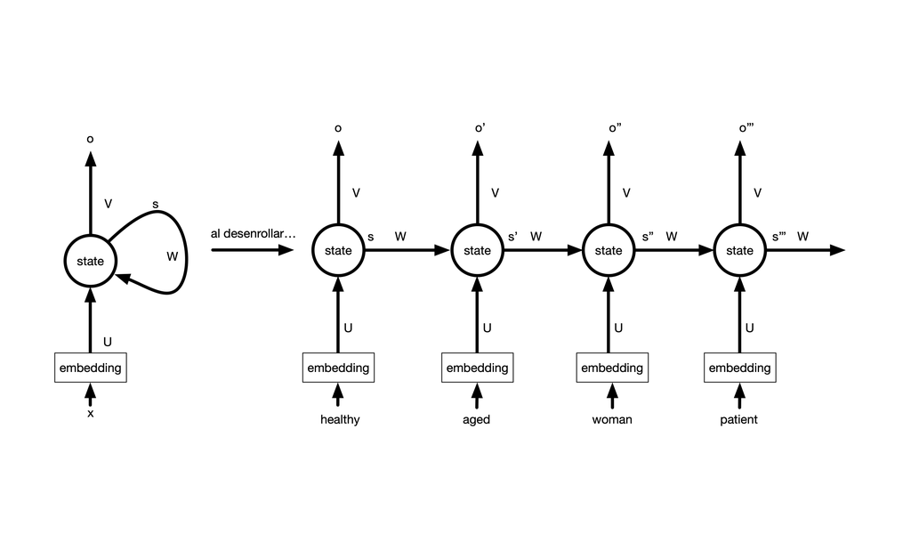

Red recurrente con el mecanismo de embedding adicional que le permite entradas codificadas en misma longitud

## 4.2 El enfoque más simple

Si lo reducimos a su mecanismo más simple, siendo $W$ el conjunto posible de palabras a usar, para una secuencia de palabras $w_1, w_2, \ldots, w_n$, podemos usar una función $f:W \rightarrow \mathbb{R}^n$ tal que la codificación del texto sea:

$$\sum_{i=1}^n f(w_i)$$

es decir simplemente la suma de las codificaciones individuales de cada palabra.

La implementación consistiría en:

- Una tabla con una entrada para cada palabra y su correspondiente codificación en $\mathbb{R}^n$
- Naturalmente, el elemento clave aquí es $f()$

## 4.3 Semántica en el contexto de vectores en $\mathbb{R}^n$

Las distintas facetas del significado de una simple palabra, ¿cómo modelarlas?

- **Similitud**: permite expresar que “manzana” es similar a “melocotón”
- **Antonimia**: nos permite modelar “fuerte” y “débil”
- **Connotaciones semánticas**:
  - “soleado” (connotación positiva) y “nublado” (negativa)
  - “comprar”, “vender” y “pagar” se refieren al mismo evento de intercambio comercial
- **Inferencia**: inducción de conocimiento no necesariamente hecho explícito (importantísimo en sistemas de preguntas y respuestas y en diálogos)

## 4.4 Textos con semántica similar

Consideremos dos textos $t_1$ y $t_2$, con longitudes $l_1$ y $l_2$, con $l_1 \neq l_2$.

**Idea 1**: Podemos representar palabras individuales en espacios n-dimensionales.

**Idea 2**: El significado de una palabra se puede modelar haciendo uso de las palabras que la rodean gramaticalmente.

> Dos palabras que suelen aparecer en entornos cuyos vecinos respectivos son similares, deben de tener significados parecidos.

### 4.4.1 Un ejemplo

Supongamos que tenemos un nuevo coche en el mercado, ClaseA, del que no sabemos nada y queremos averiguar cosas de él a partir de ver dónde aparece. Si en nuestro corpus de texto tenemos afirmaciones como:

1. “El ClaseA consume poco en autovía”
2. “El ClaseA es confortable para viajes largos”
3. “Los neumáticos del ClaseA tienen buen agarre”

Y en el pasado hemos visto sentencias similares para otros modelos:

1. “Este Audi3 tiene un consumo razonable en carretera”
2. “Tanto el Focus como el Sierra resultan cómodos en desplazamientos largos”
3. “En coches familiares como Focus y Audi3 resulta conveniente…”

Podríamos acabar deduciendo que el ClaseA es un coche familiar porque suele aparecer en expresiones similares a otros coches familiares conocidos.

**¿Podemos hacer esto computacionalmente?**

Se puede hacer simplemente contando palabras en el contexto de la palabra “ClaseA”.

## 4.5 Posibles aproximaciones algorítmicas

¿Cómo construimos vectores que nos permitan capturar la semántica de textos en lenguaje natural?

### 4.5.1 Modelo de vector de términos

Una aproximación tradicional es el modelo de vector de términos:

- Considerando un diccionario con vocabulario de tamaño $n$ ($|V|=n$)
- Un texto se representaría con un vector de $n$ valores donde el valor $i$-ésimo corresponde a la frecuencia de aparición del token $i$ del diccionario en el texto

### 4.5.2 Vector de palabras

Para representar lenguajes (no documentos), podemos usar:

- Una matriz de co-ocurrencia con dimensiones $n \times n$ (para $n$ palabras)
- Cada componente $(i,j)$ indica cuántas veces aparecen juntas las palabras $i$ y $j$

Ejemplo de matriz de co-ocurrencia (extracto):

| Term | computer | data | result | pie | sugar |
| --- | --- | --- | --- | --- | --- |
| digital | 1670 | 1683 | 85 | 5 | 4 |
| information | 3325 | 3982 | 378 | 5 | 13 |
| cherry | 2 | 8 | 9 | 442 | 25 |
| strawberry | 0 | 0 | 1 | 60 | 19 |

Representación gráfica para las palabras “digital” e “information”:

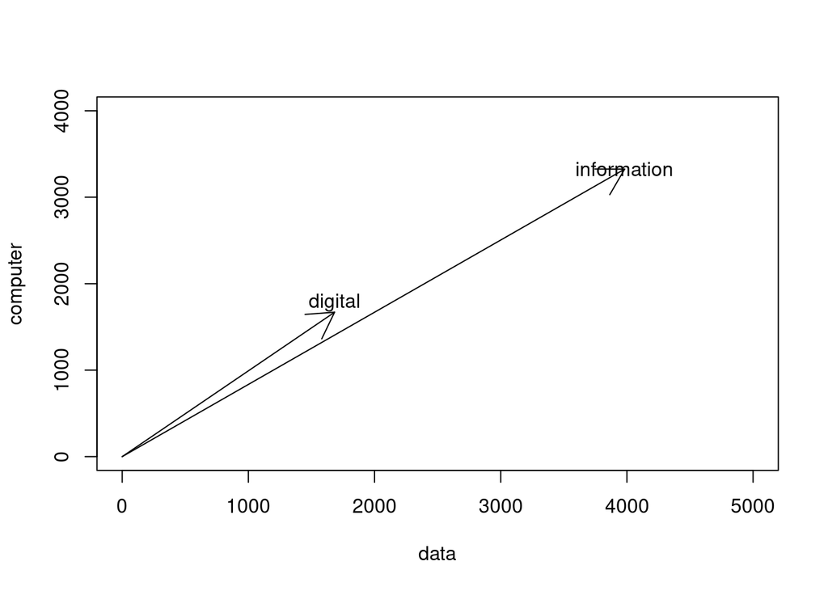

Representación de co-ocurrencia

```r
plot(NA, xlim=c(0,5000), ylim=c(0,4000),
     xlab="data", ylab="computer", lwd=3)
arrows(0,0,1683,1670)
text("digital",x=1683,y=1780)
arrows(0,0,3982,3325)
text("information",x=3982,y=3325)
```

### 4.5.3 Distancia entre palabras

Funciona bastante bien. Ambos vectores (“digital” e “information”) van prácticamente en la misma dirección (y sentido). Lo cual quiere decir que aparecen proporcionalmente similar en contextos con “data” y “computer”.

El vector “information” tiene una norma mayor simplemente porque es más común como palabra que “digital”.

**Desventaja**: No debemos olvidar que hemos de usar todas las dimensiones correspondientes al tamaño de nuestro vocabulario (vectores muy dispersos, prácticamente nulos).

Para medir la similitud entre palabras, podemos usar el ángulo formado por sus vectores. El coseno de 0° es 1 (máxima similitud).

El **coseno del ángulo** $\theta$ entre dos vectores se calcula como:

$$\cos\theta = \frac{a \cdot
b}{|a||b|}$$

Donde:

- $a \cdot b$ es el producto punto de los vectores
- $|a|$ y $|b|$ son las normas (magnitudes) de los vectores

Visualización con diferentes dimensiones:

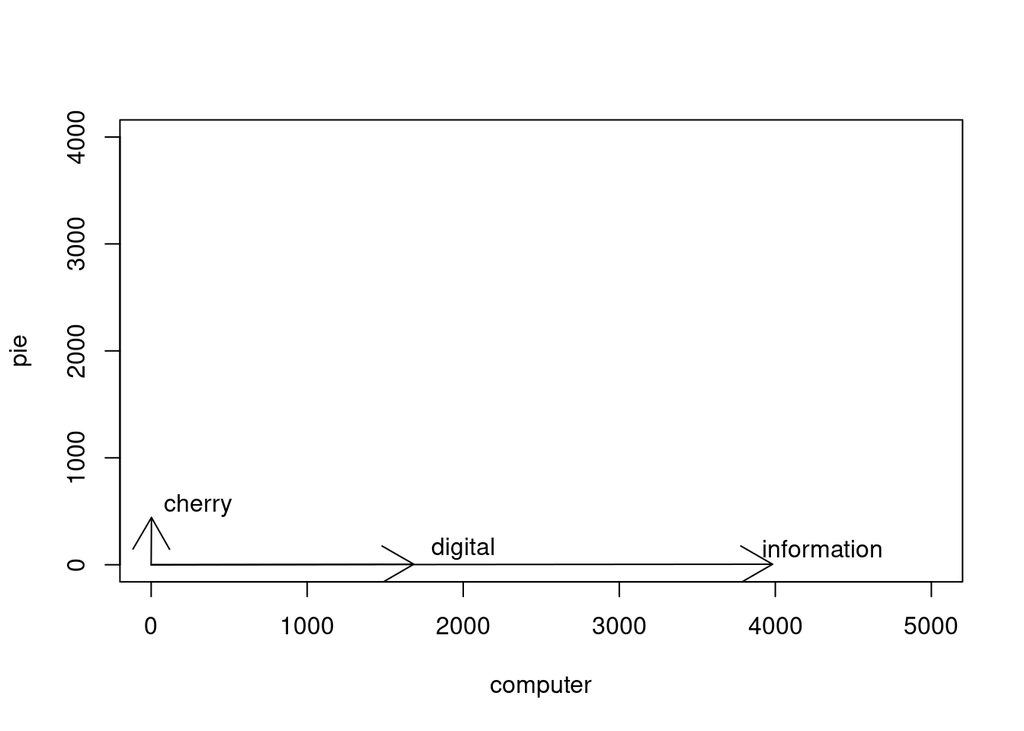

Distancia entre palabras en diferentes dimensiones

```r
plot(NA, xlim=c(0,5000), ylim=c(0,4000),
     xlab="computer", ylab="pie", lwd=3)
arrows(0,0,1683,5)
text("digital", x=2000, y=150)
arrows(0,0,3982,5)
text("information", x=4300, y=150)
arrows(0,0,2,442)
text("cherry", x=300, y=550)
```

- Podemos ver que “cherry” es prácticamente ortogonal con respecto a “digital” e “information”, cuando usamos “pie” como segunda dimensión.
- Las distancias del coseno calculadas son: $\cos(\text{cherry}, \text{information}) = 0.018$

$\cos(\text{digital}, \text{information}) = 0.996$

Más detalladamente, la representación de semántica basada en vectores de palabras muestra los problemas:

1. **Falta de contexto posicional**:
   - No captura adecuadamente la semántica del documento
   - Las palabras se tratan independientemente de su posición y contexto circundante
2. **Problema de dispersión**:
   - Genera vectores dispersos (la mayoría de componentes son cero)
   - Dimensión del vector = tamaño del vocabulario ($|V|=n$)
   - La distancia del coseno pierde efectividad porque:
     $$x^Ty = \sum_{i=1}^n x_i y_i$$
     En la mayoría de pares $(x_i,y_i)$, al menos uno de los valores es 0

## 4.6 Modelo de vectores densos (embeddings)

Los **embeddings** son un mecanismo para codificación de textos en vectores de números reales de longitud $m$, donde normalmente $m \ll n$, siendo $|V| = n$ el tamaño del vocabulario.

Matemáticamente, un embedding puede representarse como una matriz:

$$E \in \mathbb{R}^{|V| \times m}$$

donde:

- Cada fila corresponde a una palabra del vocabulario $V$
- Cada columna representa una dimensión del espacio de embedding

Este mecanismo codifica cada palabra $w \in V$ en un vector denso de $m$ valores reales:

$$e(w) \in \mathbb{R}^m$$

Para un texto $T = \{t_1, t_2, \ldots, t_k\}$ compuesto por $k$ tokens, una codificación básica del texto completo se obtiene mediante:

$$e(T) = \sum_{i=1}^k e(t_i)$$

**Ventajas de este enfoque**: 1. Resuelve el problema de los vectores dispersos (sparse vectors) 2. Reduce dimensionalidad ($m \ll n$) 3. Genera representaciones densas y continuas

**Limitaciones**:

- La suma simple ignora el contexto de cada palabra
- Todas las palabras contribuyen por igual independientemente de:
  - Su posición en el texto
  - Su relación con otras palabras
  - Su importancia semántica
- No captura relaciones sintácticas o semánticas complejas

### 4.6.1 Modelo de lenguaje de referencia

¿Cómo podemos capturar la semántica de los textos?

- Ideas complementarias
1. Si usamos una palabra con un significado central en una frase, condicionará a qué otras palabras van a acabar apareciendo a izquierda y derecha de esa palabra
2. Si miramos a las palabras a izquierda y derecha de una palabra desconocida, seguramente podremos determinar dicha palabra.

#### 4.6.1.1 Skip-gram

- El modelo skip-grama se basa en que una palabra en una frase puede usarse para predecir las palabras de su contexto posicional.
- La probabilidad de obtener un ejemplo de entrenamiento de longitud T concreto es
  $$P(\text{contexto}|\text{palabra}) = \prod_{t=1}^T
  \prod_{\substack{-m \leq j \leq m \\ j \neq 0}}
  P(w_{t+j}|w_t)$$

#### 4.6.1.2 CBOW (Continuous Bag-of-Words)

En cbow, o Continuous bag-of-words la idea es que el contexto de una palabra se puede usar para predecirla ([Mikolov et al., 2013](https://arxiv.org/abs/1301.3781))

La probabilidad de obtener un ejemplo de entrenamiento de longitud T concreto es:
$$P(\text{palabra}|\text{contexto}) = \prod_{t=1}^T
P(w_t|w_{t-m}, \ldots, w_{t-1}, w_{t+1}, \ldots, w_{t+m})$$

Donde:

- $m$: tamaño del contexto (ventana)
- $w_i$: i-ésimo token en la secuencia
- $T$: longitud de la secuencia

#### 4.6.1.3 Modelado de probabilidades

**Enfoque**:

- Entrenamiento sobre corpus textual (libros, páginas web)
- Optimización: maximizar la probabilidad de las secuencias observadas
- **Aprendizaje auto-supervisado**: no necesita etiquetas manuales

### 4.6.2 Redes neuronales en embeddings

Dicho esto, si queremos usar redes neuronales, y optimizar los pesos de la red a partir de dichos ejemplos, necesitamos una función de error del modelo de red neuronal, sobre un conjunto de secuencias.

Sea un ejemplo de entrenamiento $s$, de longitud $T$, y un contexto de longitud $m$,

Para el modelo skip-grama tenemos
$$E(s)=-\sum_{t=1}^T \sum_{-m \leq j \leq m, j \neq
0} \log p(w_{t+j}|w_t).$$

Al aplicar logaritmos al doble producto de arriba, el lector verá en seguida de dónde sale dicha función.

Una desventaja: los embeddings basados en skip-gram y CBOW son independientes del contexto en tiempo de codificación.

Cuando se codifica una palabra mediante el embedding, no se tiene en cuenta el contexto en el que aparece dicha palabra en la sentencia.

En 2017 y 2018 aparecieron TagLM, CoVe y ELMo. Basándose en el uso de RNNs para generar una representación $m$ dimensional para cada token a la entrada, usando para ello toda la cadena de entrada.

BERT modela el contexto de manera bidireccional, y es task-agnostic. Véase la figura siguiente, que compara los diferentes enfoques.

[figure not shown]

Comparación de diferentes arquitecturas basdas en transformers para models de lenguaje

# 5 Backpropagation through time

El algoritmo básico para entrenar los pesos de este tipo de redes es el de retropropagación del error a través del tiempo (BPTT). Como en todo algoritmo de optimización por gradiente, comenzamos definiendo la función de error,

$$L(h,\hat{y}) = \sum_t L_t(y_t,
\hat{y}),$$

en donde $L_t$ es la función de error (*loss* en inglés), $y_t$ es el valor de la variable a predecir en el instante $t$ y $\hat{y}_t$ es el valor predicho en ese mismo instante.

## 5.1 Backpropagation clásico

Recordemos cómo funcionaba BP clásico. Es decir, en un BP clásico, un ejemplo $u$ se propaga desde los nodos de entrada a los nodos de salida de un MLP. Una vez hecho esto, la contribución al error de cada nodo de salida $i$, que denotamos por $\delta_i$, viene dado por

$$\delta_i = \hat{y}_i(1-\hat{y}_i)(y_i -
\hat{y}_i)$$

y una vez calculado este, podemos entonces calcular la contribución de cada nodo oculto $h$ al error tal

$$\delta_h = \hat{y}_h(1-\hat{y}_h)\sum_{i
\in \text{Outputs}} w_{h,i}\delta_i$$

actualizando todos los pesos según

$$w_{i,j} \leftarrow w_{i,j} + \Delta
w_{i,j}, \quad \Delta w_{i,j} = \eta \delta_i u_{i,j},$$

y teniendo en cuenta que:

- $w_{i,j}$ es el peso de un arco que sale del nodo $i$-ésimo y llega al nodo $j$-ésimo
- $u_{i,j}$ es la entrada al nodo $j$-ésimo que llega por el arco $i$-ésimo
- Usamos $h$ para indexar nodos de la capa oculta

## 5.2 Backpropagation Through Time (BPTT)

BPTT trabaja de manera similar al BP clásico, pero ahora se ha de tener en cuenta que: 1. En el instante $t$ (en BP no hay instante alguno que considerar, todo ocurre de una vez) 2. Las salidas de cada nodo (y por tanto, la contribución de cada nodo al error) dependen de los valores anteriores del nodo 3. Nos referimos a los valores de $s_i$, con $1 \leq i \leq t$

Por tanto, cuando vayamos a derivar la función de error, debemos tener en cuenta la expresión no solo en ese instante sino en los anteriores y lo haremos de manera aditiva.

Esto se ve claro en la [Figura 2 del paper](https://arxiv.org/abs/1211.5063) que reproducimos aquí. En comparación con la figura anterior, esta figura incluye: - El proceso de inferencia hacia delante (flechas gruesas de izquierda a derecha) - Los gradientes de relevancia en la dirección opuesta

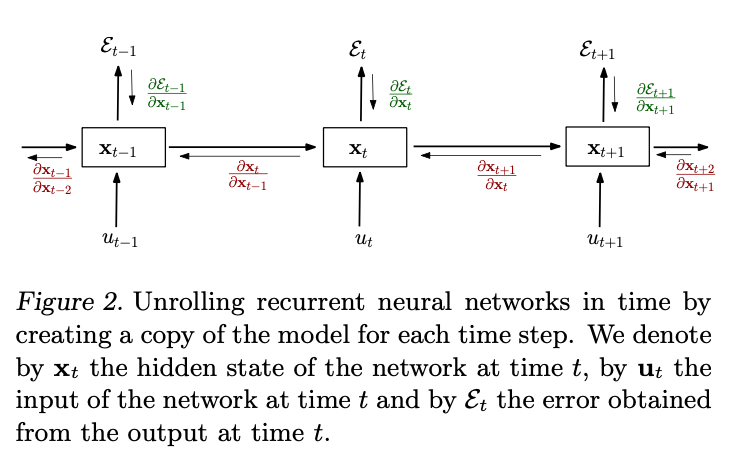

Derivaciones parciales para optimizar un gradiente en el BPTT

Como vemos, la red se desenrolla hacia delante, de tal forma que eventos pasados entran a la siguiente “copia” inmediata de la red. Por otro lado, el error de la red en el instante actual, denotado con εt se utiliza para el gradiente en el mismo instante t , aplicándose a los pesos de la red en ese instante. los elementos
$$\frac{\partial \epsilon_t}{\partial x_t}$$
en verde, son las contribuciones al error del backpropagation convencional, que se aplican en el instante correspondiente.

# 6 Capas bidireccionales

Supongamos que queremos predecir la palabra que va en un hueco intermedio de una frase. Por ejemplo, consideremos las frases:

1. “Tengo ______”
2. “Tengo hambre.”
3. “Tengo hambre, me podría comer cinco hamburguesas.”

Podemos rellenar los huecos con palabras como: - “sueño” - “poca” - “mucha”

En este ejemplo observamos claramente que: - No es suficiente con considerar solo las palabras anteriores - Se hace necesario analizar también las palabras posteriores - La red debe trabajar no solo de izquierda a derecha, sino también de derecha a izquierda

Solución: Redes Bidireccionales

Podemos rellenar los huecos con palabras como “sueño”, “poca” o “mucha”. En este ejemplo podemos ver claramente que no es suficiente con las palabras anteriores, sino que también se hace necesario mirar a las palabras posteriores, de tal forma que en lugar de que la red trabaje solo de izquierda a derecha, pueda hacerlo también de derecha a izquierda, i.e. necesitamos redes bidireccionales

Si queremos que este tipo de cosas se tengan en cuenta a la hora de entrenar nuestra red recurrente, en lugar de ejecutarla solo “hacia delante”, la mejor solución consiste en construir otra red que vaya de atrás hacia delante, lo que se conoce como capa bidireccional. En la siguiente se observa la estructura de una red

[figure not shown]

Modelo de procesamiento bidireccional, para una red recurrente bidireccional

En este tipo de redes, no solo se ha de tener en cuenta el estado $s_t$ del que hablamos antes, en las redes recurrentes unidireccionales. Se hace necesario un estado nuevo $s'_t$, que vaya en sentido contrario. Hagamos corresponder, por coherencia de notación $s_t$ con $\vec{H}_t$ y $s'_t$ con $\overleftarrow{H}_t$.

Ahora, cada estado se procesará de forma diferente tal que:

$$\vec{H}_t = f(X_t W^{(f)} + \vec{H}_{t-1} U^{(f)} + b^{(f)})$$

$$\overleftarrow{H}_t = f(X_t W^{(b)} + \overleftarrow{H}_{t-1} U^{(b)} +
b^{(b)})$$

para los casos forward ($f$) y backwards ($b$). La inferencia final de la red concatena $\vec{H}_t$ y $\overleftarrow{H}_t$ en un solo $H_t$ para hacer la inferencia como siempre, según:

$$o_t = o(V H_t + b_o)$$

**Componentes**:

- $\vec{H}_t$: Estado forward (left-to-right)
- $\overleftarrow{H}_t$: Estado backward (right-to-left)
- $W^{(f)}, W^{(b)}$: Matrices de pesos para las entradas
- $U^{(f)}, U^{(b)}$: Matrices de pesos recurrentes
- $b^{(f)}, b^{(b)}$: Vectores de bias
- $V, b_o$: Parámetros de la capa de salida
- $f$: Función de activación (ej. tanh, ReLU)
- $o$: Función de salida (ej. softmax)

# 7 Redes LSTM

Las redes LSTM (Long Short Term Memory) son una clase especial de RNNs capaces de aprender dependencias a largo plazo. Fueron introducidas por Hochreiter y Schmidhuber en 1997, y han sido refinadas y popularizadas desde entonces.

Este tipo de redes funciona bien en una gran variedad de problemas, y son usadas ampliamente. Una versión más actual y eficiente son las GRU (Gated Recurrent Units) pero el principio básico es el mismo.

Lo primero que debemos hacer notar es que un nodo LSTM es más complejo que un nodo recurrente clásico. La particularidad de las redes LSTM es que en ellas se controla en todo momento

- qué cantidad de información se recuerda del estado actual
- qué cantidad de memoria del estado anterior se va a utilizar en la composición de la memoria del estado actual.
- no solo modula qué cantidad de memoria entra y sale del nodo en cada instante, sino también cómo esta información se combina y actualiza para influir en el estado futuro de la red.
- Dicho mecanismo se aprende durante el entrenamiento.

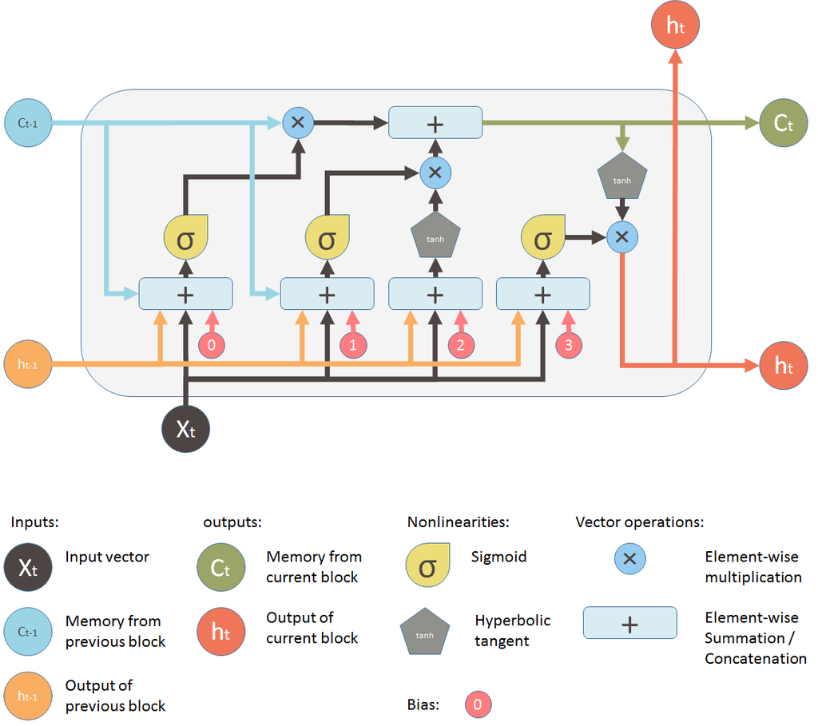

Red LSTM

1. Se refiere a la memoria mantenida por el nodo LSTM
2. Se crea a partir del flujo que aparece representado de izquierda a derecha en la parte superior del nodo
3. Se alimenta de los cuatro flujos que van de abajo a arriba y se incorporan al flujo principal con simples operaciones vectoriales de producto o suma

Cada uno de estos flujos desemboca en:

- Una sigmoide ($\sigma$), que genera valores en $[0,1]$
- O una tangente hiperbólica ($\tanh$), que genera valores en $[-1,1]$

Los datos de entrada a un nodo LSTM son:

- La entrada en el instante $t$ correspondiente al ejemplo de entrenamiento actual ($x_t$)
- El estado oculto $h_{t-1}$
- La memoria de la celda en el instante anterior $C_{t-1}$.

## 7.1 La puerta de salida $o_t$

Antes de comenzar, asumimos que:

1. Nos encontramos en el instante $t-1$.
2. Acabamos de calcular el estado de la celda $C_{t-1}$.
3. Queremos generar la salida $h_{t-1}$, que servirá como entrada en el siguiente instante $t$.

Ahora, en el paso $t$, la salida $h_t$ se obtiene a partir de dos elementos clave:

1. **El estado de la celda** $C_t$.
2. **La compuerta de salida** $o_t$, que se calcula mediante una sigmoide y se alimenta de:
   - La entrada en el instante actual $x_t$.
   - La salida del estado oculto en el instante anterior $h_{t-1}$.
   - Un sesgo $b_o$.

La expresión de la compuerta de salida es:

$$o_t = \sigma(W_o h_{t-1} + U_o x_t + b_o)$$

Luego, la salida $h_t$ se obtiene aplicando la compuerta $o_t$ sobre una versión escalada del estado de la celda $C_t$ mediante la función tangente hiperbólica:

$$h_t = o_t \odot \tanh(C_t)$$

Donde:  
- $o_t$ es la *output gate*, que decide cuánto del estado de la celda $C_t$ se usará en la salida.  
- $\odot$ representa el producto de Hadamard (componente a componente).  
- La función $\tanh$ ayuda a mantener el gradiente bajo control, evitando valores excesivamente grandes.

En contraste con una RNN clásica, donde el estado oculto se pasa de manera directa al siguiente instante, la LSTM introduce mecanismos de control. La *output gate* permite entrenar qué parte del estado previo debe conservarse y usarse en la salida, modulando el porcentaje de información utilizada.

La parte del diagrama que se corresponde con este proceso es la señal que va de $C_t$ y $o_t$ a $h_t$.

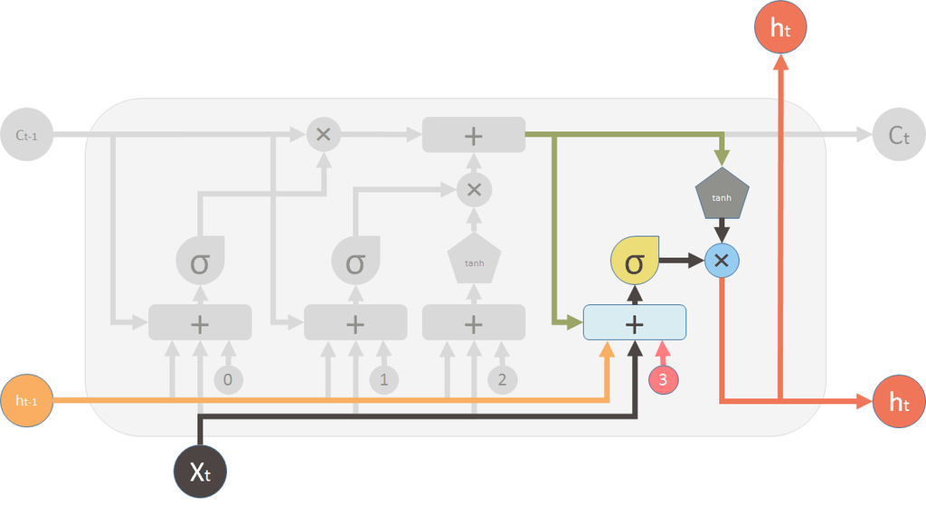

## 7.2 La puerta de olvido

Una vez hemos construido la salida $h_{t-1}$ y la hemos pasado a la siguiente celda, el siguiente paso es decidir cómo modular $C_{t-1}$. Esta decisión se realiza mediante un nodo con salida sigmoidal, denominado *forget layer*. Recibe $h_{t-1}$ y $x_t$, y devuelve un vector de números entre 0 y 1 que se multiplica elemento a elemento con el estado $C_{t-1}$.

En esta puerta de olvido, que denotamos con $f_t$, las ecuaciones son:

$$\begin{aligned}
f_t &= \sigma(W_f h_{t-1} + U_f x_t + b_f) \\
C_t &= C_{t-1} \times f_t
\end{aligned}$$

Y se refiere a la parte destacada del nodo.

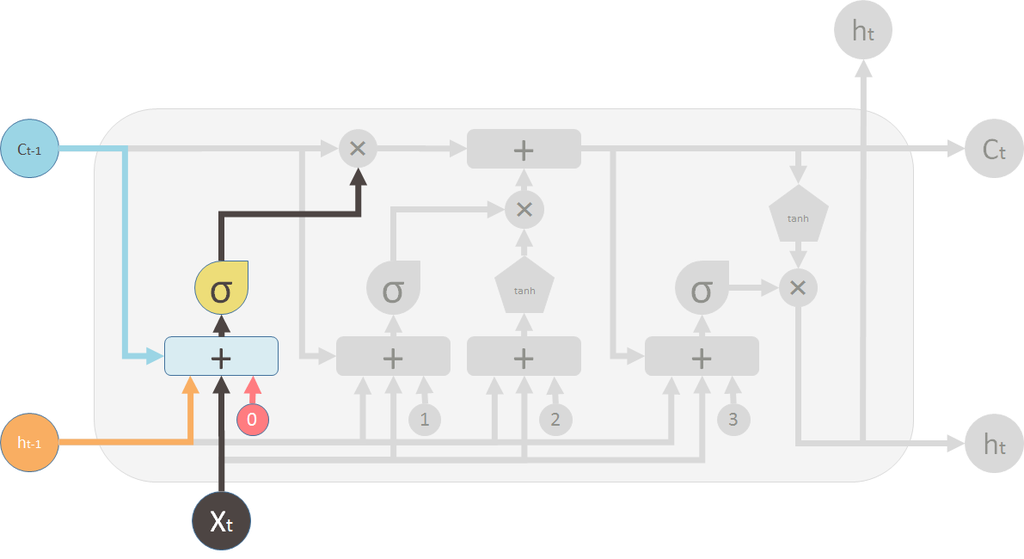

## 7.3 La puerta de entrada $i_t$

Ahora necesitamos incorporar a nuestro nodo LSTM el nodo clásico de red recurrente en el que la salida dependerá de la entrada actual y del estado anterior, tal y como hemos visto al principio. Y luego, por otro lado, también modularemos cuánto de esa salida se genera al exterior, mediante una multiplicación punto con un vector del mismo número de componentes, producidos por una sigmoide. Como este estado es un $C_t$ temporal ya que, en realidad, se ha de integrar con $C_{t-1}$ más adelante, lo denotamos con $\tilde{C}_t$. Tenemos entonces que:

$$\tilde{C}_t = \tanh(W_{\tilde{C}} h_{t-1} + U_{\tilde{C}} x_t +
b_{\tilde{C}})$$

que sería idéntica al de una RNN clásica cambiando $h_{t-1}$ por $s_{t-1}$. Ahora, introducimos una mejora propia de las LSTM, al permitir, mediante el producto con la salida de la puerta sigmoidal, que denotamos con $i_t$, decidir cuánto usamos de cada estado, mediante:

$$\begin{aligned}
i_t &= \sigma(W_i h_{t-1} + U_i x_t + b_i) \\
C_t &= C_{t-1} \times f_t + i_t \times \tilde{C}_t
\end{aligned}$$

y que destacamos en la figura.

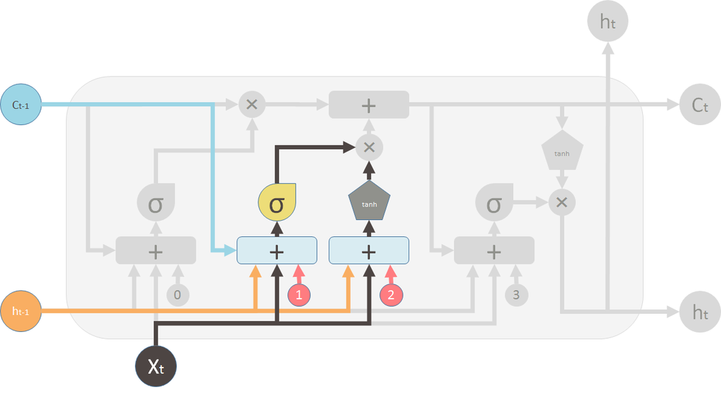

La puerta de entrada $i_t$

[Post resumen](https://www.linkedin.com/pulse/lstm-gates-input-forget-output-morteza-heidari-mzbdf/)

# 8 Conclusiones

La recurrencia en redes neuronales consiste en utilizar como input para las capas de la red en el instante $t$ la salida de dichas capas en el instante $t−1$.

Estas redes son más costosas de entrenar (más imprevisibles, lentas en convergencia)

Las redes convencionales tienen un horizonte temporal limitado (vanishing gradients!). Las redes LSTM alivian este problema (más complejas, aun más costosas de entrenar)

# 9 Referencias usadas

El curso de la Univ. Michigan de redes convolucionales de [Justin Johnson](https://web.eecs.umich.edu/~justincj/teaching/eecs498/WI2022/).

La Wikipedia para referirnos al modelo de [vector de términos](https://en.wikipedia.org/wiki/Vector_space_model) para representar semántica de textos

El libro del lingüista computacional [Jurafsky y Martin, 2023](https://web.stanford.edu/~jurafsky/slp3/)

El libro Dive into deep learning de [Zhang, Lipton et al.](https://d2l.ai/).